# Exercise 2. Regression and model validation

## 4. Diagnostic plots

In the *plot()* function, the plots Residuals vs Fitted values, Normal QQ-plot and Residuals vs Leverage are called by the argument *which*. They respectively correspond to a *which* of 1, 2 and 5.

### Residuals vs Fitted values

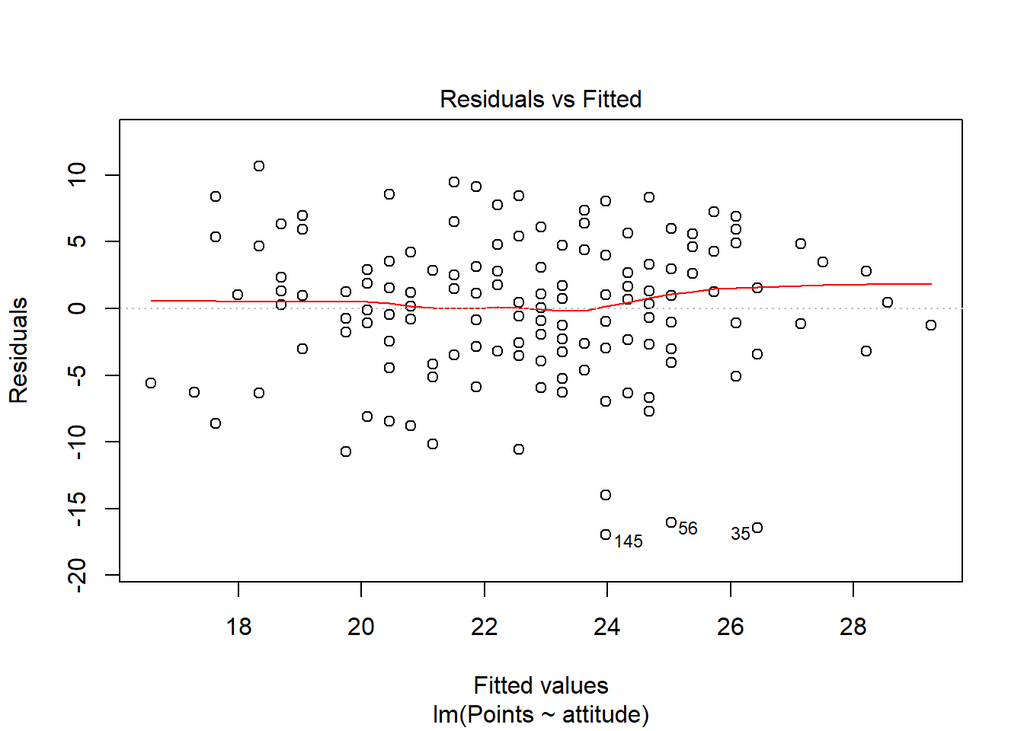

```r
plot(my_model2, which = 1)
```

The assumption that the size of the errors does not depend on *attitude* is reasonable, because the plots are reasonably spread and there is no pattern.

### Normal QQ-plot

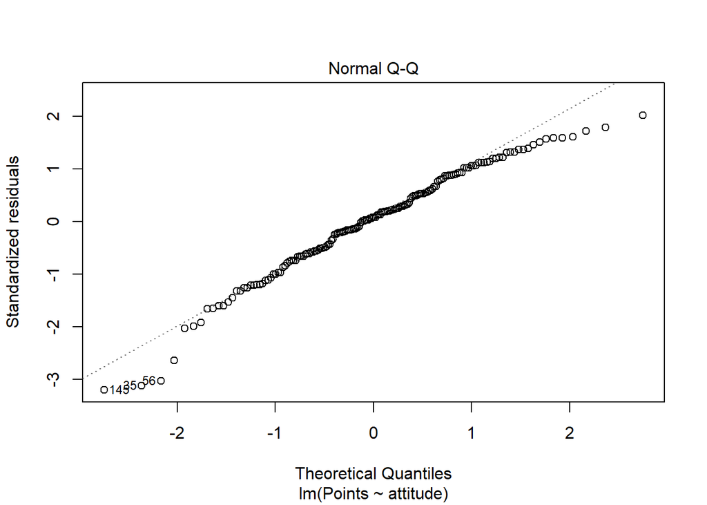

```r
plot(my_model2, which = 2)
```

The assumption that the errors are normally distributed is reasonable.

### Residuals vs Leverage

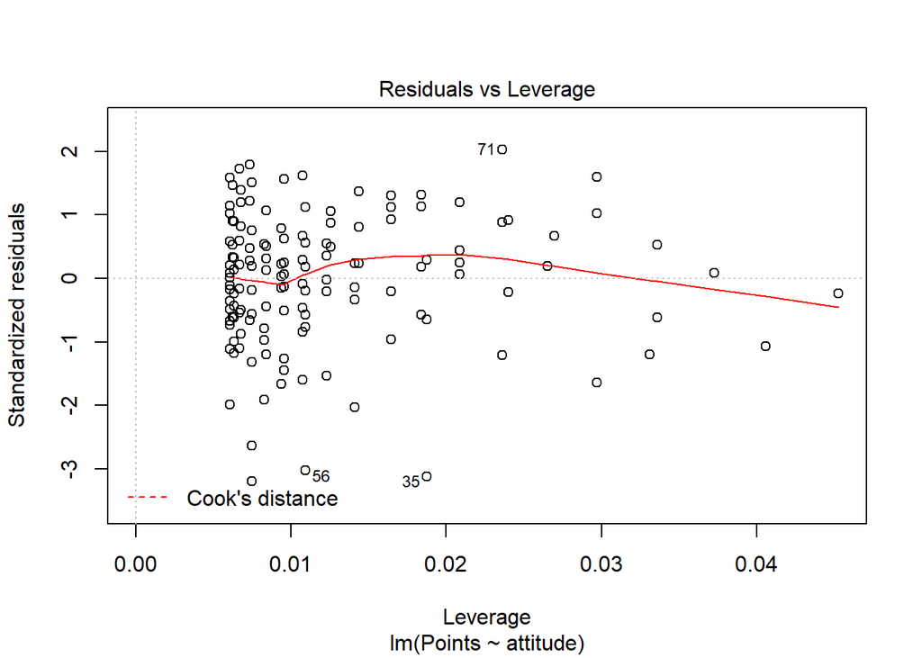

```r
plot(my_model2, which = 5)
```

There is no observation having an unusual high impact.